# Guide to missSuperLearner

Pan Zhao, Nicolas Gatulle, Julie Josse and Antoine Chambaz

September 5, 2022

```r
library(missSuperLearner)
```

# 1 Introduction

This vignette is a practical guide for using the `missSuperLearner` package, which builds on the `SuperLearner` package. If you are unfamiliar with the `SuperLearner` package, it is advisable to read this [Guide to SuperLearner](https://cran.r-project.org/web/packages/SuperLearner/vignettes/Guide-to-SuperLearner.html) first.

# 2 Dataset

We use the `diabetes` dataset which is available from the `VIM` package.

```r
# Load the dataset from the VIM package
data(diabetes, package = "VIM")

# Info of the diabetes dataset
?VIM::diabetes

# Summary of the dataset
summary(diabetes)
```

```
#>   Pregnancies        Glucose      BloodPressure    SkinThickness
#>  Min.   : 1.000   Min.   : 44.0   Min.   : 24.00   Min.   : 7.00
#>  1st Qu.: 2.000   1st Qu.: 99.0   1st Qu.: 64.00   1st Qu.:22.00
#>  Median : 4.000   Median :117.0   Median : 72.00   Median :29.00
#>  Mean   : 4.495   Mean   :121.7   Mean   : 72.41   Mean   :29.15
#>  3rd Qu.: 7.000   3rd Qu.:141.0   3rd Qu.: 80.00   3rd Qu.:36.00
#>  Max.   :17.000   Max.   :199.0   Max.   :122.00   Max.   :99.00
#>  NA's   :111      NA's   :5       NA's   :35       NA's   :227
#>     Insulin            BMI        DiabetesPedigreeFunction      Age
#>  Min.   : 14.00   Min.   :18.20   Min.   :0.0780           Min.   :21.00
#>  1st Qu.: 76.25   1st Qu.:27.50   1st Qu.:0.2437           1st Qu.:24.00
#>  Median :125.00   Median :32.30   Median :0.3725           Median :29.00
#>  Mean   :155.55   Mean   :32.46   Mean   :0.4719           Mean   :33.24
#>  3rd Qu.:190.00   3rd Qu.:36.60   3rd Qu.:0.6262           3rd Qu.:41.00
#>  Max.   :846.00   Max.   :67.10   Max.   :2.4200           Max.   :81.00
#>  NA's   :374      NA's   :11
#>  Outcome
#>  no :500
#>  yes:268
#>
#>
#>
#>
#>
```

```r
# Check for missing data
colSums(is.na(diabetes))
```

```
#>              Pregnancies                  Glucose            BloodPressure
#>                      111                        5                       35
#>            SkinThickness                  Insulin                      BMI
#>                      227                      374                       11
#> DiabetesPedigreeFunction                      Age                  Outcome
#>                        0                        0                        0
```

```r
# Get the outcome variable from the data
outcome <- diabetes$Outcome

# Create a dataframe to contain the explanatory variables
data <- subset(diabetes, select = -Outcome)

# Check structure of our dataframe
str(data)
```

```
#> 'data.frame':    768 obs. of  8 variables:
#>  $ Pregnancies             : int  6 1 8 1 NA 5 3 10 2 8 ...
#>  $ Glucose                 : int  148 85 183 89 137 116 78 115 197 125 ...
#>  $ BloodPressure           : int  72 66 64 66 40 74 50 NA 70 96 ...
#>  $ SkinThickness           : int  35 29 NA 23 35 NA 32 NA 45 NA ...
#>  $ Insulin                 : int  NA NA NA 94 168 NA 88 NA 543 NA ...
#>  $ BMI                     : num  33.6 26.6 23.3 28.1 43.1 25.6 31 35.3 30.5 NA ...
#>  $ DiabetesPedigreeFunction: num  0.627 0.351 0.672 0.167 2.288 ...
#>  $ Age                     : int  50 31 32 21 33 30 26 29 53 54 ...
```

```r
# Review the dimensions
dim(data)
```

```
#> [1] 768   8
```

```r
# Set a seed for reproducibility
set.seed(1)

# Reduce to a dataset of 400 observations to speed up model fitting.
train_obs <- sample(nrow(data), 400)

# X is our training sample.
x_train <- data[train_obs, ]

# Create a holdout set for evaluating model performance.
# Note: cross-validation is even better than a single holdout sample.
x_holdout <- data[-train_obs, ]

# The outcome must be a numeric vector
outcome <- as.numeric(outcome == "yes")

y_train <- outcome[train_obs]
y_holdout <- outcome[-train_obs]

# Review the outcome variable distribution.
table(y_train, useNA = "ifany")
```

```
#> y_train
#>   0   1
#> 260 140
```

# 3 Review available models

```r
SuperLearner::listWrappers()
```

```
#> All prediction algorithm wrappers in SuperLearner:
#>  [1] "SL.bartMachine"      "SL.bayesglm"         "SL.biglasso"
#>  [4] "SL.caret"            "SL.caret.rpart"      "SL.cforest"
#>  [7] "SL.earth"            "SL.extraTrees"       "SL.gam"
#> [10] "SL.gbm"              "SL.glm"              "SL.glm.interaction"
#> [13] "SL.glmnet"           "SL.ipredbagg"        "SL.kernelKnn"
#> [16] "SL.knn"              "SL.ksvm"             "SL.lda"
#> [19] "SL.leekasso"         "SL.lm"               "SL.loess"
#> [22] "SL.logreg"           "SL.mean"             "SL.nnet"
#> [25] "SL.nnls"             "SL.polymars"         "SL.qda"
#> [28] "SL.randomForest"     "SL.ranger"           "SL.ridge"
#> [31] "SL.rpart"            "SL.rpartPrune"       "SL.speedglm"
#> [34] "SL.speedlm"          "SL.step"             "SL.step.forward"
#> [37] "SL.step.interaction" "SL.stepAIC"          "SL.svm"
#> [40] "SL.template"         "SL.xgboost"
#>
#> All screening algorithm wrappers in SuperLearner:
#> [1] "All"
#> [1] "screen.corP"           "screen.corRank"        "screen.glmnet"
#> [4] "screen.randomForest"   "screen.SIS"            "screen.template"
#> [7] "screen.ttest"          "write.screen.template"
```

Note that we add a new `grf` learner ([generalized random forests](https://grf-labs.github.io/grf/index.html)). Look at the code for a model.

```r
SL.grf
```

```
#> function (Y, X, newX, family, obsWeights, ...)
#> {
#>     .SL.require("grf")
#>     if (family$family == "gaussian") {
#>         fit <- grf::regression_forest(X, Y, sample.weights = obsWeights)
#>         pred <- stats::predict(fit, newX)$predictions
#>     }
#>     if (family$family == "binomial") {
#>         Y <- as.factor(Y)
#>         fit <- grf::probability_forest(X, Y, sample.weights = obsWeights)
#>         pred <- stats::predict(fit, newX)$predictions[, "1"]
#>     }
#>     fit <- list(object = fit)
#>     class(fit) <- c("SL.grf")
#>     out <- list(pred = pred, fit = fit)
#>     return(out)
#> }
#> <bytecode: 0x1332df158>
#> <environment: namespace:missSuperLearner>
```

For maximum accuracy one might try at least the following models: glmnet, randomForest, XGBoost, SVM, and bartMachine. These should ideally be tested with multiple hyperparameter settings for each algorithm.

# 4 Fit individual models

Let’s fit 2 separate models: lasso (sparse, penalized OLS) and random forest. We specify family = binomial() because we are predicting a binary outcome, aka classification. With a continuous outcome we would specify family = gaussian().

```r
set.seed(1)
# Fit lasso model
sl_lasso <- missSuperLearner(Y = y_train, X = x_train, family = binomial(),
                             imputeAlgo = c("mean", "median", "mice"),
                             SL.library = "SL.glmnet")
sl_lasso
```

```
#>
#> Call:
#> missSuperLearner(Y = y_train, X = x_train, family = binomial(), SL.library = "SL.glmnet",
#>     imputeAlgo = c("mean", "median", "mice"))
#>
#>
#>                           Risk      Coef
#> SL.glmnet_All_mean   0.1690821 0.8127358
#> SL.glmnet_All_median 0.1693482 0.0000000
#> SL.glmnet_All_mice   0.1714403 0.1872642
```

```r
# Review the elements in the missSuperLearner object
names(sl_lasso)
```

```
#>  [1] "call"              "libraryNames"      "SL.library"
#>  [4] "imputeAlgo"        "mice.params"       "X"
#>  [7] "SL.predict"        "coef"              "library.predict"
#> [10] "Z"                 "cvRisk"            "family"
#> [13] "fitLibrary"        "cvFitLibrary"      "varNames"
#> [16] "validRows"         "method"            "whichScreen"
#> [19] "control"           "cvControl"         "errorsInCVLibrary"
#> [22] "errorsInLibrary"   "metaOptimizer"     "env"
#> [25] "times"
```

```r
# Here is the risk of the best model (discrete SuperLearner winner).
sl_lasso$cvRisk[which.min(sl_lasso$cvRisk)]
```

```
#> SL.glmnet_All_mean
#>          0.1690821
```

```r
# Here is the raw glmnet result object:
str(sl_lasso$fitLibrary$SL.glmnet_All_mean$object, max.level = 1)
```

```
#> List of 12
#>  $ lambda    : num [1:62] 0.211 0.193 0.175 0.16 0.146 ...
#>  $ cvm       : num [1:62] 1.31 1.28 1.26 1.23 1.21 ...
#>  $ cvsd      : num [1:62] 0.0555 0.0551 0.0519 0.0493 0.0473 ...
#>  $ cvup      : num [1:62] 1.36 1.34 1.31 1.28 1.26 ...
#>  $ cvlo      : num [1:62] 1.25 1.23 1.2 1.18 1.17 ...
#>  $ nzero     : Named int [1:62] 0 1 1 1 1 1 1 1 3 3 ...
#>   ..- attr(*, "names")= chr [1:62] "s0" "s1" "s2" "s3" ...
#>  $ call      : language glmnet::cv.glmnet(x = X, y = Y, weights = obsWeights, lambda = NULL, type.measure = loss,      nfolds = nfolds, f| __truncated__
#>  $ name      : Named chr "Binomial Deviance"
#>   ..- attr(*, "names")= chr "deviance"
#>  $ glmnet.fit:List of 13
#>   ..- attr(*, "class")= chr [1:2] "lognet" "glmnet"
#>  $ lambda.min: num 0.00894
#>  $ lambda.1se: num 0.0575
#>  $ index     : int [1:2, 1] 35 15
#>   ..- attr(*, "dimnames")=List of 2
#>  - attr(*, "class")= chr "cv.glmnet"
```

```r
# Fit random forest.
sl_rf <- missSuperLearner(Y = y_train, X = x_train, family = binomial(),
                          imputeAlgo = c("mean", "median", "mice"),
                          SL.library = "SL.ranger")
sl_rf
```

```
#>
#> Call:
#> missSuperLearner(Y = y_train, X = x_train, family = binomial(), SL.library = "SL.ranger",
#>     imputeAlgo = c("mean", "median", "mice"))
#>
#>
#>                           Risk Coef
#> SL.ranger_All_mean   0.1660411    1
#> SL.ranger_All_median 0.1691019    0
#> SL.ranger_All_mice   0.1721956    0
```

Risk is a measure of model accuracy or performance. We want our models to minimize the estimated risk, which means the model is making the fewest mistakes in its prediction. It’s basically the mean-squared error in a regression model, but you can customize it if you want.

SuperLearner is using cross-validation to estimate the risk on future data. By default it uses 10 folds; use the cvControl argument to customize.

# 5 Fit multiple models

Instead of fitting the models separately and looking at the performance (lowest risk), we can fit them simultaneously. SuperLearner will then tell us which one is best (discrete winner) and also create a weighted average of multiple models.

We include the mean of Y (“SL.mean”) as a benchmark algorithm. It is a very simple prediction so the more complex algorithms should do better than the sample mean. We hope to see that it isn’t the best single algorithm (discrete winner) and has a low weight in the weighted-average ensemble. If it is the best algorithm something has likely gone wrong.

```r
set.seed(1)
sl <- missSuperLearner(Y = y_train, X = x_train, family = binomial(),
                       imputeAlgo = c("mean", "median", "mice"),
                       SL.library = c("SL.mean", "SL.glmnet", "SL.ranger"))
sl
```

```
#>
#> Call:
#> missSuperLearner(Y = y_train, X = x_train, family = binomial(), SL.library = c("SL.mean",
#>     "SL.glmnet", "SL.ranger"), imputeAlgo = c("mean", "median", "mice"))
#>
#>
#>                           Risk       Coef
#> SL.mean_All_raw      0.2280864 0.00000000
#> SL.glmnet_All_mean   0.1692748 0.00000000
#> SL.glmnet_All_median 0.1687926 0.54694438
#> SL.glmnet_All_mice   0.1714224 0.00000000
#> SL.ranger_All_mean   0.1706635 0.35995406
#> SL.ranger_All_median 0.1708190 0.07833690
#> SL.ranger_All_mice   0.1727597 0.01476465
```

```r
# Review how long it took to run the SuperLearner:
sl$times$everything
```

```
#>    user  system elapsed
#>   5.566   0.237   5.547
```

So we have an automatic ensemble of multiple learners based on the cross-validated performance of those learners, nice!

# 6 Predict on new data

Now that we have an ensemble let’s predict back on our holdout dataset and review the results.

```r
# Predict back on the holdout dataset.
# onlySL is set to TRUE so we don't fit algorithms that had weight = 0, saving computation.
pred <- predict(sl, newdata = x_holdout, X = x_train, onlySL = TRUE)

# Check the structure of this prediction object.
str(pred)
```

```
#> List of 2
#>  $ pred           : num [1:368, 1] 0.0421 0.1714 0.0836 0.4969 0.5972 ...
#>  $ library.predict: num [1:368, 1:7] 0 0 0 0 0 0 0 0 0 0 ...
```

```r
# Review the columns of $library.predict.
summary(pred$library.predict)
```

```
#>        V1          V2          V3                V4          V5
#>  Min.   :0   Min.   :0   Min.   :0.02655   Min.   :0   Min.   :0.0000
#>  1st Qu.:0   1st Qu.:0   1st Qu.:0.14315   1st Qu.:0   1st Qu.:0.1354
#>  Median :0   Median :0   Median :0.27936   Median :0   Median :0.2745
#>  Mean   :0   Mean   :0   Mean   :0.34220   Mean   :0   Mean   :0.3422
#>  3rd Qu.:0   3rd Qu.:0   3rd Qu.:0.47399   3rd Qu.:0   3rd Qu.:0.5337
#>  Max.   :0   Max.   :0   Max.   :0.95580   Max.   :0   Max.   :0.8900
#>        V6               V7
#>  Min.   :0.0020   Min.   :0.0020
#>  1st Qu.:0.1435   1st Qu.:0.1240
#>  Median :0.2873   Median :0.2690
#>  Mean   :0.3471   Mean   :0.3320
#>  3rd Qu.:0.5367   3rd Qu.:0.5145
#>  Max.   :0.8946   Max.   :0.9220
```

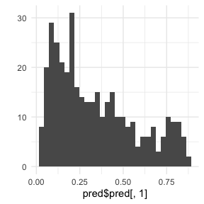

```r
# Histogram of our predicted values.
library(ggplot2)
qplot(pred$pred[, 1]) + theme_minimal()
```

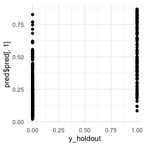

```r
# Scatterplot of original values (0, 1) and predicted values.
# Ideally we would use jitter or slight transparency to deal with overlap.
qplot(y_holdout, pred$pred[, 1]) + theme_minimal()
```

```r
# Review AUC - Area Under Curve
pred_rocr <- ROCR::prediction(pred$pred, y_holdout)
auc <- ROCR::performance(pred_rocr, measure = "auc", x.measure = "cutoff")@y.values[[1]]
auc
```

```
#> [1] 0.856543
```

AUC can range from 0.5 (no better than chance) to 1.0 (perfect). So at 0.85 we are looking pretty good!

# 7 Fit ensemble with external cross-validation

What we don’t have yet is an estimate of the performance of the ensemble itself. Right now we are just hopeful that the ensemble weights are successful in improving over the best single algorithm.

In order to estimate the performance of the SuperLearner ensemble we need an “external” layer of cross-validation, also called nested cross-validation. We generate a separate holdout sample that we don’t use to fit the SuperLearner, which allows it to be a good estimate of the SuperLearner’s performance on unseen data. Typically we would run 10 or 20-fold external cross-validation, but even 5-fold is reasonable.

Another nice result is that we get standard errors on the performance of the individual algorithms and can compare them to the SuperLearner.

```r
set.seed(1)

# Don't have timing info for the CV.SuperLearner unfortunately.
# So we need to time it manually.

system.time({
  # This will take about 2x as long as the previous SuperLearner.
  cv_sl <- CV.missSuperLearner(Y = y_train, X = x_train, family = binomial(),
                               # For a real analysis we would use V = 10.
                               cvControl = list(V = 2), innerCvControl = list(list(V=2)),
                               imputeAlgo = c("mean", "median", "mice"),
                               SL.library = c("SL.mean", "SL.glmnet", "SL.ranger"))
})
# We run summary on the cv_sl object rather than simply printing the object.
summary(cv_sl)
```

```
#>
#> Call:
#> CV.missSuperLearner(Y = y_train, X = x_train, family = binomial(), SL.library = c("SL.mean",
#>     "SL.glmnet", "SL.ranger"), imputeAlgo = c("mean", "median", "mice"),
#>     cvControl = list(V = 2), innerCvControl = list(list(V = 2)))
#>
#> Risk is based on: Mean Squared Error
#>
#> All risk estimates are based on V =  2
#>
#>             Algorithm     Ave        se     Min     Max
#>         Super Learner 0.17580 0.0100311 0.15761 0.19400
#>           Discrete SL 0.17687 0.0104065 0.15802 0.19573
#>       SL.mean_All_raw 0.22818 0.0072133 0.22368 0.23268
#>    SL.glmnet_All_mean 0.17304 0.0106829 0.15802 0.18807
#>  SL.glmnet_All_median 0.17261 0.0108009 0.15741 0.18781
#>    SL.glmnet_All_mice 0.17342 0.0102748 0.15627 0.19057
#>    SL.ranger_All_mean 0.18294 0.0101310 0.17015 0.19573
#>  SL.ranger_All_median 0.18133 0.0100726 0.16825 0.19440
#>    SL.ranger_All_mice 0.18282 0.0099762 0.16827 0.19736
```

```r
# Review the distribution of the best single learner as external CV folds.
table(simplify2array(cv_sl$whichDiscreteSL))
```

```
#>
#> SL.glmnet_All_mean SL.ranger_All_mean
#>                  1                  1
```

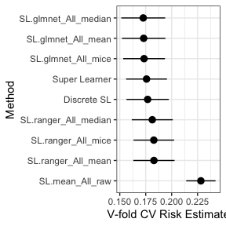

```r
# Plot the performance with 95% CIs (use a better ggplot theme).
plot(cv_sl) + theme_bw()
```

We see based on the outer cross-validation that SuperLearner is statistically tying with the best algorithm. Our benchmark learner “SL.mean” shows that we get a nice improvement over a naive guess based only on the mean. We could also add “SL.glm” to compare to logistic regression.

# 8 Customize a model hyperparameter

Hyperparameters are the configuration settings for an algorithm. OLS has no hyperparameters but essentially every other algorithm does.

There are two ways to customize a hyperparameter: make a new learner function, or use create.Learner().

Let’s make a variant of random forest that fits more trees, which may increase our accuracy and can’t hurt it (outside of small random variation).

```r
# Review the function argument defaults at the top.
SL.ranger
```

```
#> function (Y, X, newX, family, obsWeights, num.trees = 500, mtry = floor(sqrt(ncol(X))),
#>     write.forest = TRUE, probability = family$family == "binomial",
#>     min.node.size = ifelse(family$family == "gaussian", 5, 1),
#>     replace = TRUE, sample.fraction = ifelse(replace, 1, 0.632),
#>     num.threads = 1, verbose = T, ...)
#> {
#>     .SL.require("ranger")
#>     if (family$family == "binomial") {
#>         Y = as.factor(Y)
#>     }
#>     if (is.matrix(X)) {
#>         X = data.frame(X)
#>     }
#>     fit <- ranger::ranger(`_Y` ~ ., data = cbind(`_Y` = Y, X),
#>         num.trees = num.trees, mtry = mtry, min.node.size = min.node.size,
#>         replace = replace, sample.fraction = sample.fraction,
#>         case.weights = obsWeights, write.forest = write.forest,
#>         probability = probability, num.threads = num.threads,
#>         verbose = verbose)
#>     pred <- predict(fit, data = newX)$predictions
#>     if (family$family == "binomial") {
#>         pred = pred[, "1"]
#>     }
#>     fit <- list(object = fit, verbose = verbose)
#>     class(fit) <- c("SL.ranger")
#>     out <- list(pred = pred, fit = fit)
#>     return(out)
#> }
#> <bytecode: 0x120cf2948>
#> <environment: namespace:SuperLearner>
```

```r
# Create a new function that changes just the ntree argument.
# (We could do this in a single line.)
# "..." means "all other arguments that were sent to the function"
SL.rf.better = function(...) {
  SL.ranger(..., num.trees = 1000)
}

set.seed(1)

# Fit the CV.SuperLearner.
# We use V = 3 to save computation time; for a real analysis use V = 10 or 20.
cv_sl <- CV.missSuperLearner(Y = y_train, X = x_train, family = binomial(), cvControl = list(V=3),
                             imputeAlgo = c("mean", "median", "mice"),
                             SL.library = c("SL.mean", "SL.glmnet", "SL.rf.better", "SL.ranger"))
```

```r
# Review results.
summary(cv_sl)
```

```
#>
#> Call:
#> CV.missSuperLearner(Y = y_train, X = x_train, family = binomial(), SL.library = c("SL.mean",
#>     "SL.glmnet", "SL.rf.better", "SL.ranger"), imputeAlgo = c("mean", "median",
#>     "mice"), cvControl = list(V = 3))
#>
#> Risk is based on: Mean Squared Error
#>
#> All risk estimates are based on V =  3
#>
#>                Algorithm     Ave        se     Min     Max
#>            Super Learner 0.16979 0.0098089 0.16167 0.17771
#>              Discrete SL 0.17243 0.0105484 0.16288 0.18122
#>          SL.mean_All_raw 0.22863 0.0072248 0.21984 0.24188
#>       SL.glmnet_All_mean 0.17207 0.0103712 0.16121 0.18122
#>     SL.glmnet_All_median 0.17110 0.0104618 0.16069 0.17943
#>       SL.glmnet_All_mice 0.17239 0.0102227 0.16288 0.18113
#>    SL.rf.better_All_mean 0.17323 0.0098295 0.17067 0.17533
#>  SL.rf.better_All_median 0.17324 0.0098739 0.17200 0.17525
#>    SL.rf.better_All_mice 0.17780 0.0098309 0.16839 0.18345
#>       SL.ranger_All_mean 0.17498 0.0100178 0.17142 0.17814
#>     SL.ranger_All_median 0.17577 0.0100110 0.17327 0.17727
#>       SL.ranger_All_mice 0.17814 0.0098391 0.17014 0.18280
```

Looks like our new RF is not improving performance. This implies that the original 500 trees had already reached the performance plateau - a maximum accuracy that RF can achieve unless other settings are changed (e.g. max nodes).

For comparison we can do the same hyperparameter customization with create.Learner().

```r
# Customize the defaults for random forest.
learners <- create.Learner("SL.ranger", params = list(num.trees = 1000))

# Look at the object.
learners
```

```
#> $grid
#> NULL
#>
#> $names
#> [1] "SL.ranger_1"
#>
#> $base_learner
#> [1] "SL.ranger"
#>
#> $params
#> $params$num.trees
#> [1] 1000
```

```r
# List the functions that were created
learners$names
```

```
#> [1] "SL.ranger_1"
```

```r
# Review the code that was automatically generated for the function.
# Notice that it's exactly the same as the function we made manually.
SL.ranger_1
```

```
#> function (...)
#> SL.ranger(..., num.trees = 1000)
```

```r
set.seed(1)

# Fit the CV.SuperLearner.
# We use V = 3 to save computation time; for a real analysis use V = 10 or 20.
cv_sl <- CV.missSuperLearner(Y = y_train, X = x_train, family = binomial(), V = 3,
                             imputeAlgo = c("mean", "median", "mice"),
                             SL.library = c("SL.mean", "SL.glmnet", learners$names, "SL.ranger"))

# Review results.
summary(cv_sl)
```

```
#>
#> Call:
#> CV.missSuperLearner(Y = y_train, X = x_train, V = 3, family = binomial(),
#>     SL.library = c("SL.mean", "SL.glmnet", learners$names, "SL.ranger"),
#>     imputeAlgo = c("mean", "median", "mice"))
#>
#> Risk is based on: Mean Squared Error
#>
#> All risk estimates are based on V =  3
#>
#>               Algorithm     Ave        se     Min     Max
#>           Super Learner 0.16979 0.0098089 0.16167 0.17771
#>             Discrete SL 0.17243 0.0105484 0.16288 0.18122
#>         SL.mean_All_raw 0.22863 0.0072248 0.21984 0.24188
#>      SL.glmnet_All_mean 0.17207 0.0103712 0.16121 0.18122
#>    SL.glmnet_All_median 0.17110 0.0104618 0.16069 0.17943
#>      SL.glmnet_All_mice 0.17239 0.0102227 0.16288 0.18113
#>    SL.ranger_1_All_mean 0.17323 0.0098295 0.17067 0.17533
#>  SL.ranger_1_All_median 0.17324 0.0098739 0.17200 0.17525
#>    SL.ranger_1_All_mice 0.17780 0.0098309 0.16839 0.18345
#>      SL.ranger_All_mean 0.17498 0.0100178 0.17142 0.17814
#>    SL.ranger_All_median 0.17577 0.0100110 0.17327 0.17727
#>      SL.ranger_All_mice 0.17814 0.0098391 0.17014 0.18280
```

We get exactly the same results between the two methods of creating a custom learner.